# Growth, age, and firm size

Use `sample_growth_tb` to compare distributions of log growth over 2010–2011 by beginning-of-period sales and firm age classes. Create density plots by sales class and by age class, and plot mean excess functions by sales class for a sample restricted by sales and age.

## 1 Setting sample conditions

```r
library(tidyverse)
library(pins)
library(hrbrthemes)
theme_set(theme_ipsum(base_size = 12, axis_title_size = 13))
board <- board_folder("../Zipf_law_board_replicate_simulation")
```

```r
library(scattermore)
```

**Sample selection and class construction**

Load growth data and calculate firm age `age` as the beginning year extracted from the period label minus establishment year `birth_year`. For periods starting in 2010, select observations with industry codes `ind_class` whose first two digits are 01–61 or 68–92. Classify beginning-of-period sales and age as follows.

- Sales: classify positive beginning-of-period sales `pre_sale`, measured in thousands of yen, using boundaries $10^3,10^{3.5},\ldots,10^8$
- Age: classify beginning-of-period ages into 0–4, 5–9, subsequent five-year intervals through 70–74, and 75 or older  
  Assign missing or negative ages to `age_other`.

```r
sample_growth_tb <- board |> pin_read("sample_growth_tb", type = "qs2") |>
  mutate(age = as.numeric(str_c(20, str_sub(year, 6,7))) - birth_year)

size_depend_tb <- sample_growth_tb |>
  filter(str_sub(year, -2) == "10",
         str_sub(ind_class, 1,2) %in% str_pad(c(1:61, 68:92), 2, pad = 0)) |>
  mutate(
    size_class = ifelse(
      is.na(pre_sale), "size_other",
      cut(
        pre_sale,
        breaks = c(-Inf, 0, 10^{seq(3, 8, by = .5)}, Inf),
        labels = c("size_other", "size_3_below", str_c("size_", seq(3.5, 8, by = .5)), "size_8_over"),
        right = T, include.lowest = T) |> as.character()),
    age_class = ifelse(
      is.na(age) | age < 0, "age_other",
      cut(
        age,
        breaks = c(seq(0, 75, by = 5), Inf),
        labels = c(str_c("age_", str_pad(seq(0, 70, by = 5), 2, pad = "0")), "age_75_plus"),
        right = FALSE, include.lowest = TRUE) |> as.character())) |>
  filter(!is.na(growth), !is.na(size_class), !is.na(age_class))

growth_2010_tb <- size_depend_tb |>
  filter(year == "g_11_10")

density_tb <- growth_2010_tb |>
  filter(growth != 0, abs(growth) < 3.5)
```

Define the age intervals for the legend in `age_class_labels`. Display the sales-class boundaries in yen by using labels equal to 1000 times the boundaries originally defined in thousands of yen.

```r
age_class_labels <- c(
  "age_00" = "0–4",   "age_05" = "5–9",   "age_10" = "10–14", "age_15" = "15–19",
  "age_20" = "20–24", "age_25" = "25–29", "age_30" = "30–34", "age_35" = "35–39",
  "age_40" = "40–44", "age_45" = "45–49", "age_50" = "50–54", "age_55" = "55–59",
  "age_60" = "60–64", "age_65" = "65–69", "age_70" = "70–74",
  "age_75_plus" = "75+"
)

size_class_labels <- c(
  size_other   = '"Other/NA"',
  size_3_below = 'paste("(", 0,    ", ",  10^6,    "]")',
  size_3.5     = 'paste("(", 10^6, ", ", 10^{6.5}, "]")',
  size_4       = 'paste("(", 10^{6.5}, ", ", 10^7, "]")',
  size_4.5     = 'paste("(", 10^7, ", ", 10^{7.5}, "]")',
  size_5       = 'paste("(", 10^{7.5}, ", ", 10^8, "]")',
  size_5.5     = 'paste("(", 10^8, ", ", 10^{8.5}, "]")',
  size_6       = 'paste("(", 10^{8.5}, ", ", 10^9, "]")',
  size_6.5     = 'paste("(", 10^9, ", ", 10^{9.5}, "]")',
  size_7       = 'paste("(", 10^{9.5}, ", ", 10^{10}, "]")',
  size_7.5     = 'paste("(", 10^{10}, ", ", 10^{10.5}, "]")',
  size_8       = 'paste("(", 10^{10.5}, ", ", 10^{11}, "]")',
  size_8_over  = 'paste("(", 10^{11}, ", ", infinity, "  ]")'
)
```

## 2 Growth densities by sales and age class

**Densities by sales class**

Use `density_tb` to compare growth densities by beginning-of-period sales class. For this figure, retain `size_other` and `age_other` and impose no additional sales floor or firm age restrictions. Use a linear horizontal scale for growth and a logarithmic vertical scale for density. Display a horizontal range of −2 to 2 and a vertical range of $10^{-2.5}$ to $10^1$.

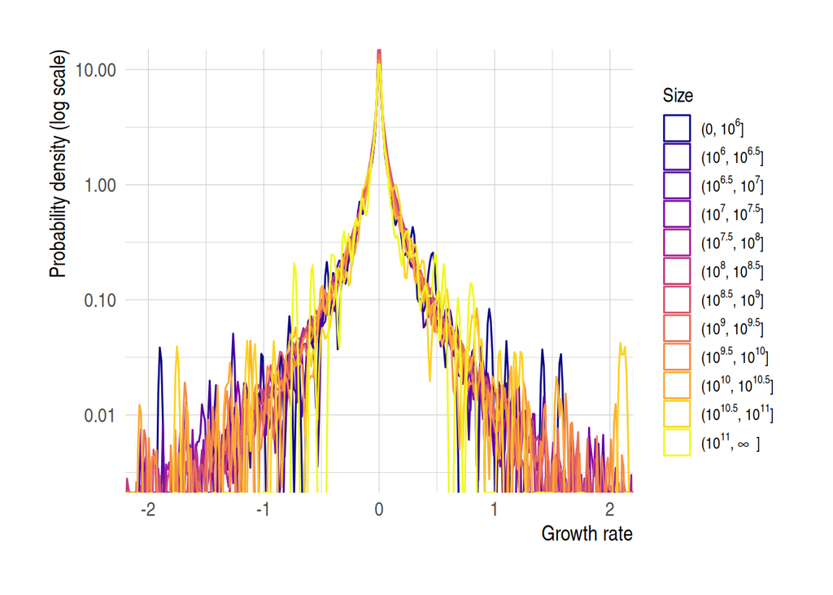

```r
density_tb |>
ggplot() +
  geom_density(aes(growth, color = size_class)) +
  scale_color_viridis_d(
    option = "C",
    labels = \(x) parse(text = size_class_labels[x])
  ) +
  scale_y_log10() +
  coord_cartesian(xlim = c(-2.0, 2.0), ylim = c(10^{-2.5}, 10^1)) +
  labs(x = "Growth rate",
       y = "Probability density (log scale)",
       color = "Size") +
  theme(axis.title = element_text(face = "bold"))
ggsave(filename = "growth_df_size.png", path = "graph")
```

**Densities by age class**

Exclude `age_other` from the common density sample `density_tb` and compare growth densities by age class. Include `age_00` (ages 0–4) and impose no additional sales-class restrictions. Use the same scales and display ranges as in the sales-class figure.

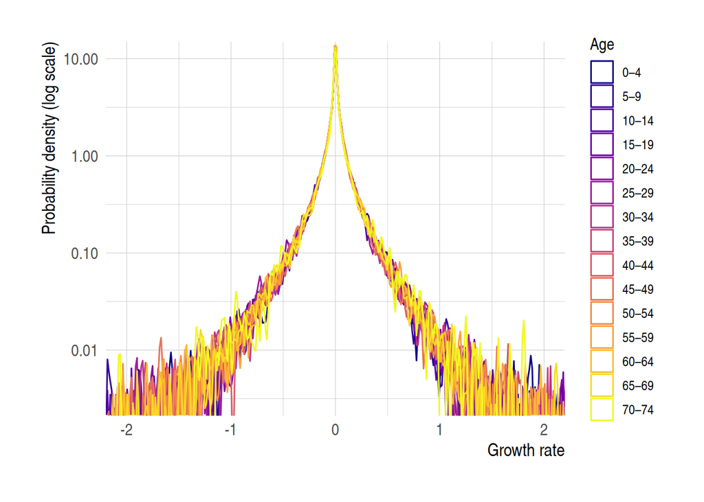

```r
density_tb |>
  filter(age_class != "age_other") |>
ggplot() +
  geom_density(aes(growth, color = age_class)) +
  scale_color_viridis_d(
    option = "C",
    labels = age_class_labels) +
  scale_y_log10() +
  coord_cartesian(xlim = c(-2.0, 2.0), ylim = c(10^{-2.5}, 10^1)) +
  labs(x = "Growth rate",
       y = "Probability density (log scale)",
       color = "Age") +
  theme(axis.title = element_text(face = "bold"))
ggsave(filename = "growth_df_age.png", path = "graph")
```

## 3 Mean excess functions with sales and age restrictions

From `growth_2010_tb`, select observations with beginning-of-period sales of at least $10^{4.5}$ in thousands of yen and beginning-of-period age of at least 5 years (excluding `age_other` and `age_00`, the ages 0–4 class). Do not apply the density-plot restrictions excluding zero growth and requiring an absolute value below 3.5.

Let $g_{(i)}$ denote growth rates in descending order within each class. Calculate the mean excess function as follows.

$$m_{\mathrm{excess},i}=\frac{1}{i-1}\sum_{j=1}^{i-1}g_{(j)}-g_{(i)}, \qquad i\geq2.$$

Use colors to distinguish sales classes. Display a horizontal range of 0.1–4 and a vertical range of 0–1.

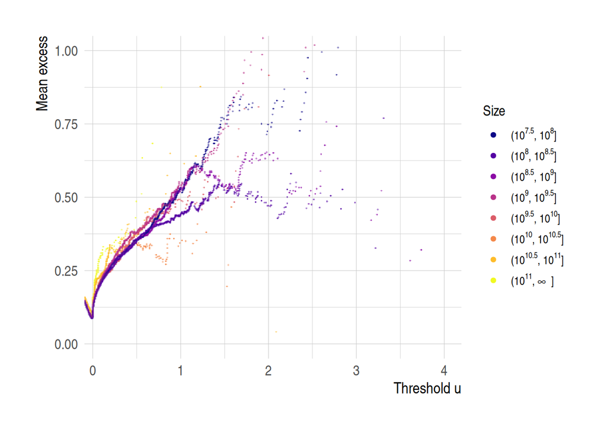

```r
growth_2010_tb |>
  filter(pre_sale >= 10^{4.5},
         age_class != "age_other", age_class != "age_00") |>
  arrange(desc(growth)) |>
  group_by(size_class) |>
  mutate(m_excess = lag(cummean(growth)) - growth) |>
ggplot(aes(growth, m_excess, color = size_class)) +
  geom_scattermore(pointsize = 1.5) +
  scale_color_viridis_d(
    option = "C",
    labels = \(x) parse(text = size_class_labels[x])
  ) +
  coord_cartesian(xlim = c(0.1, 4), ylim = c(0, 1.0)) +
  labs(x = "Threshold u",
       y = "Mean excess",
       color = "Size") +
  theme(axis.title = element_text(face = "bold"))
ggsave(filename = "mean_excess_relevant.png", path = "graph")
```